# Deep Learning project Part A

## Background Research

The EMNIST (Extended Modified National Institute of Standards and Technology) letters dataset is an extension of the original MNIST dataset. It contains 28x28 grayscale images of handwritten letters, with 26 classes (A-Z). The dataset merges uppercase and lowercase versions of each letter into the same class, which makes classification harder as some uppercase and lowercase letters look very similar.

CNNs are well suited for image classification tasks as they can automatically learn spatial features like edges and curves through convolutional filters, unlike fully connected networks which treat each pixel independently and lose spatial information.

**Source**

- Cohen, G., Afshar, S., Tapson, J., & van Schaik, A. (2017). EMNIST: an extension of MNIST to handwritten letters. Retrieved from http://arxiv.org/abs/1702.05373

```python
import pandas as pd
import numpy as np
import matplotlib.pyplot as plt
import seaborn as sns
import tensorflow as tf
from tensorflow.keras.models import Sequential
from tensorflow.keras.layers import Dense, Conv2D, MaxPooling2D, Flatten, BatchNormalization, Dropout
from sklearn.metrics import confusion_matrix, precision_score, recall_score
from sklearn.model_selection import train_test_split
from tensorflow.keras.utils import to_categorical
```

```python
#df = pd.read_csv("/content/drive/MyDrive/Colab Notebooks/emnist-letters.csv", header=None)
df = pd.read_csv("emnist-letters.csv", header=None)
```

# Data Exploration & Cleaning

Check the dataset to understand its structure, check for invalid labels or duplicates, and visualise how the data looks.

```python
print('Exploring the data')
print(f'Dataset Shape: {df.shape}')
```

```
Exploring the data
Dataset Shape: (99040, 785)
```

```python
# Split into labels and pixels
labels = df.iloc[:, 0].values
pixels = df.iloc[:, 1:].values
```

## Before cleaning

Visualise Class distribution and sample images before cleaning to get a baseline to compare to after cleaning. Identify any obvious anomalies such as missing classes and corrupted images

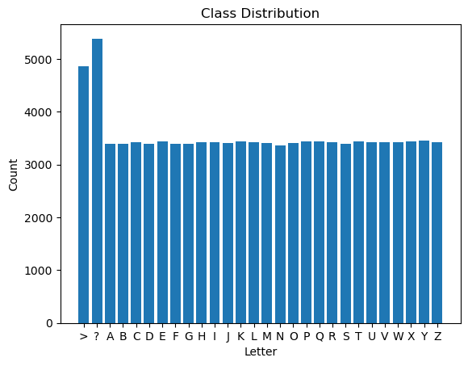

```python
# Class distribution
unique, counts = np.unique(labels, return_counts=True)
plt.bar([chr(ord('A') + i - 1) for i in unique], counts)
plt.title('Class Distribution')
plt.xlabel('Letter')
plt.ylabel('Count')
plt.show()
```

```
Displaying Sample images
```

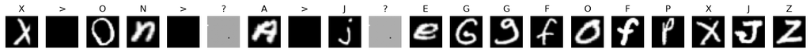

```python
print("Displaying Sample images")

def show_images(pixels, labels, n=10):
    fig, axes = plt.subplots(1, n, figsize=(15, 3))
    for i, ax in enumerate(axes):
        img = pixels[i].reshape(28, 28).T
        ax.imshow(img, cmap='gray')
        ax.set_title(chr(ord('A') + labels[i] - 1))
        ax.axis('off')
    plt.tight_layout()
    plt.show()

show_images(pixels, labels, n=20)
```

## Apply cleaning steps

```python
#Filter out invalid labels (-1 and -2)
df = df[df.iloc[:, 0] > 0].reset_index(drop=True)
# Split into labels and pixels
labels = df.iloc[:, 0].values
pixels = df.iloc[:, 1:].values
```

```python
num_dupes = df.duplicated().sum()
print(f"Duplicate rows: {num_dupes}")
df = df.drop_duplicates().reset_index(drop=True)

# Update pixels after deduplication
labels = df.iloc[:, 0].values
pixels = df.iloc[:, 1:].values

all_zero_rows = (pixels == 0).all(axis=1).sum()
print(f"All-zero image rows: {all_zero_rows}")
```

```
Duplicate rows: 2
All-zero image rows: 0
```

## After Cleaning

- **Removed Invalid Rows**: Rows with labels -1 and -2, which fall outside the valid EMNIST label range of 1–26 (A-Z). Seen in the sample images, -1 (>) produces a completely black image, and -2 (?) produces an almost fully grey image with a black dot. Both contain no letter information.
- **Removed Duplicate Rows**: Found 2 exact duplicate rows where both the label and all 784 pixel values were identical. While negligible at 99040 rows, duplicates are removed as standard practice to keep the dataset clean.

Check the distribution and Pixel Intensity of to understand the data better

## Class distribution

The class distribution is balanced, with class sizes ranging from 3,365 to 3,453 samples across all 26 letters. The difference between the smallest and largest class is only 88 samples, so no class weighting or resampling is needed before training.

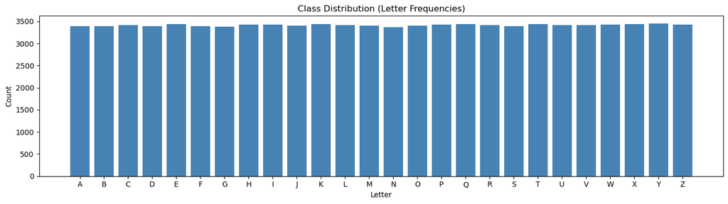

```
Min class count: 3365, Max class count: 3453
```

```python
plt.figure(figsize=(14, 4))
unique, counts = np.unique(labels, return_counts=True)
plt.bar([chr(ord('A') + i - 1) for i in unique], counts, color='steelblue')
plt.title('Class Distribution (Letter Frequencies)')
plt.xlabel('Letter')
plt.ylabel('Count')
plt.tight_layout()
plt.show()
print(f"Min class count: {counts.min()}, Max class count: {counts.max()}")
```

## Pixel Intensity Analysis

Most pixels in the dataset are black (value 0), which represents the background of each image. The spike at 255 shows the white pixels that are the letter strokes. This shows that only a small portion of pixels contain the letter itself. Normalising the pixel values from 0-255 down to 0-1 helps the model train more stably by reducing the range.

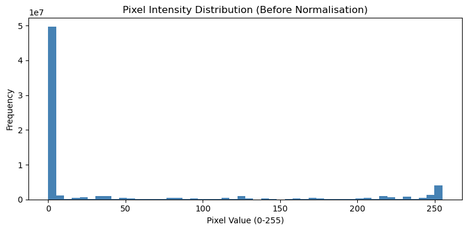

```python
plt.figure(figsize=(8, 4))
plt.hist(pixels.flatten(), bins=50, color='steelblue', edgecolor='none')
plt.title('Pixel Intensity Distribution (Before Normalisation)')
plt.xlabel('Pixel Value (0-255)')
plt.ylabel('Frequency')
plt.tight_layout()
plt.show()
```

```
Displaying Sample images
```

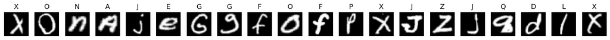

```python
print("Displaying Sample images")
show_images(pixels, labels, n=20)
```

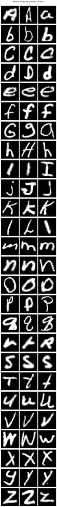

```python
# Show 3 samples per letter to show handwriting variation
fig, axes = plt.subplots(26, 3, figsize=(6, 52))

for i, letter_idx in enumerate(range(1, 27)):
    mask = np.where(labels == letter_idx)[0]
    samples = mask[:3]
    for j, idx in enumerate(samples):
        img = pixels[idx].reshape(28, 28).T
        axes[i, j].imshow(img, cmap='gray')
        axes[i, j].axis('off')
        if j == 0:
            axes[i, j].set_ylabel(chr(ord('A') + letter_idx - 1),
                                   rotation=0, labelpad=15, fontsize=12)

plt.suptitle('Sample Images per Letter (3 samples)', y=1.001)
plt.tight_layout()
plt.savefig('plot.png')
plt.show()
```

### Sample Image Analysis

From the sample images, clear variation can be seen across the dataset:

- **Tilt**: Visible in several letters like F, K, L, R and T, where samples appear at different angles; use rotation to stabilise the image
- **Style variation**: The dataset merges uppercase and lowercase into the same class, so the model must learn very different versions of the same letter, e.g. A and a, G and g, L and l
- **Shift**: Handwritten letters aren't always perfectly centered. Using shift augmentation forces the model to learn the shape of the letter regardless of its position in the frame, preventing it from over-relying on center-aligned pixels.

## Data Preprocessing

Before training, the raw pixel data needs to be transformed into a format the model can learn from effectively. The data is preprocessed in the following steps:

1. Split into train (80%), validation (10%) and test (10%) using train test split with stratify=labels to keep class distribution balanced across all splits
2. Pixel values normalised from 0-255 to 0-1
3. Use one hot encoding for the labels
4. Images reshaped to 28x28x1 for CNN input
5. Images transposed to correct EMNIST's column-major storage (eg. the letters are vertical without transpose)

```python
X_train, X_temp, y_train, y_temp = train_test_split(pixels, labels, test_size=0.2, random_state=42, stratify=labels)
X_val, X_test, y_val, y_test = train_test_split(X_temp, y_temp, test_size=0.5, random_state=42, stratify=y_temp)
```

```python
print(f"Train: {X_train.shape[0]} samples")
print(f"Val:   {X_val.shape[0]} samples")
print(f"Test:  {X_test.shape[0]} samples")
print(f"Total: {X_train.shape[0] + X_val.shape[0] + X_test.shape[0]} samples")
```

```
Train: 71038 samples
Val:   8880 samples
Test:  8880 samples
Total: 88798 samples
```

```python
# Normalise pixel values to range [0, 1]
print('Normalise pixel values to range [0,1]')
X_train = X_train / 255
X_test = X_test /255
X_val = X_val / 255
print('Normalisation complete')
```

```
Normalise pixel values to range [0,1]
Normalisation complete
```

```python
# One hot encoding
print('One hot encoding labels')
y_train = to_categorical(y_train - 1, num_classes=26)
y_val = to_categorical(y_val - 1, num_classes=26)
y_test = to_categorical(y_test - 1, num_classes=26)
print('One hot encoding done')
```

```
One hot encoding labels
One hot encoding done
```

```python
# Reshape pixels to 28x28x1 arrays and transpose
# EMNIST images are stored column-major, so they need to be transposed
print('Reshaping and transposing')
X_train = X_train.reshape(-1, 28, 28, 1)
X_val = X_val.reshape(-1, 28, 28, 1)
X_test = X_test.reshape(-1, 28, 28, 1)

# Transpose to correct orientation
X_train = np.transpose(X_train, (0, 2, 1, 3))
X_val = np.transpose(X_val, (0, 2, 1, 3))
X_test = np.transpose(X_test, (0, 2, 1, 3))
print('Reshaping and transposing done')
```

```
Reshaping and transposing
Reshaping and transposing done
```

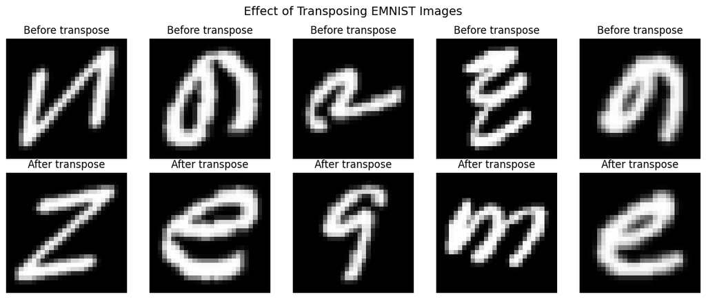

```python
# Show that the transposed images now match natural handwriting
fig, axes = plt.subplots(2, 5, figsize=(12, 5))
for i in range(5):
    # Without transpose (reshape only)
    raw = X_train[i].transpose(1, 0, 2)  # undo the transpose to show original
    axes[0, i].imshow(raw.reshape(28, 28), cmap='gray')
    axes[0, i].set_title('Before transpose')
    axes[0, i].axis('off')
    # With transpose (what we actually use)
    axes[1, i].imshow(X_train[i].reshape(28, 28), cmap='gray')
    axes[1, i].set_title('After transpose')
    axes[1, i].axis('off')
plt.suptitle('Effect of Transposing EMNIST Images', fontsize=14)
plt.tight_layout()
plt.show()
```

```python
# set seed to ensure same results when reran
import random
random.seed(42)
np.random.seed(42)
tf.random.set_seed(42)
```

## Baseline CNN Model

The baseline model uses a standard CNN architecture to establish a performance floor that the improved model should beat.

The baseline model consists of the following:

- 3 convolutional blocks with increasing filter sizes (32, 64, 128) to learn features from simple edges to more complex shapes
- BatchNormalization after each Conv layer to stabilise training
- Flatten layer followed by Dense(256) with Dropout(0.5) to reduce overfitting
- Output layer with 26 neurons and softmax activation for classification
- Adam optimizer for adaptive learning rates that don't need manual tuning
- Categorical crossentropy loss for multi-class classification with one hot encoded labels

```python
print('Defining CNN model')
model = Sequential([
    Conv2D(32, (3,3), activation='relu', input_shape=(28,28,1)),
    BatchNormalization(),
    MaxPooling2D((2,2)),

    Conv2D(64, (3,3), activation='relu'),
    BatchNormalization(),
    MaxPooling2D((2,2)),

    Conv2D(128, (3,3), activation='relu'),
    BatchNormalization(),

    Flatten(),
    Dense(256, activation='relu'),
    Dropout(0.5),
    Dense(26, activation='softmax')
])
print('Successfully defined')
```

```
Defining CNN model
Successfully defined
```

```python
# Compile the model with optimizer, loss function, and evaluation metrics
print("Compiling the model...")
model.compile(optimizer='adam',
              loss='categorical_crossentropy',
              metrics=['accuracy'])
print("Model compiled with 'adam' optimizer and 'categorical_crossentropy' loss.\n")
```

```
Compiling the model...
Model compiled with 'adam' optimizer and 'categorical_crossentropy' loss.
```

```python
from tensorflow.keras.callbacks import EarlyStopping, ModelCheckpoint, ReduceLROnPlateau

callbacks = [
    EarlyStopping(monitor='val_loss', patience=5, restore_best_weights=True), # stops if val_loss doesn't improve for 5 epochs
    ModelCheckpoint('best_model_v1.h5', monitor='val_accuracy', save_best_only=True), # saves best model
    ReduceLROnPlateau(monitor='val_loss', patience=3, factor=0.5, min_lr=1e-6) # reduces learning rate if val_loss is stagnant
]

history = model.fit(
    X_train, y_train,
    epochs=50,
    batch_size=32,
    validation_data=(X_val, y_val),
    callbacks=callbacks
)

loss, accuracy = model.evaluate(X_test, y_test)
print(f'Test accuracy: {accuracy:.4f}')
```

```
Test accuracy: 0.9474
```

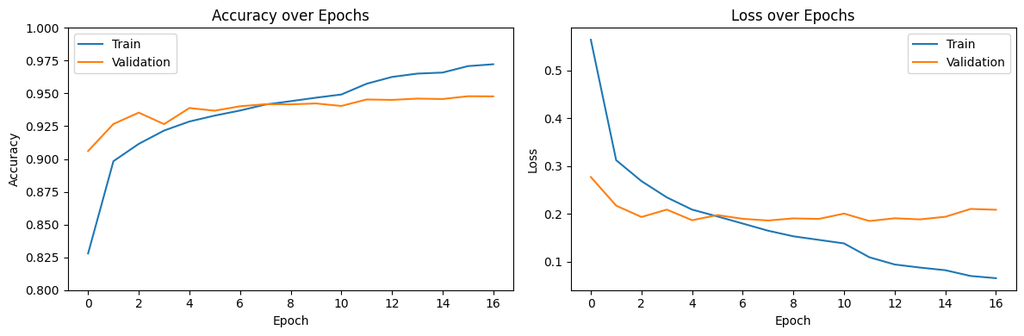

```python
# Plot training vs validation accuracy
plt.figure(figsize=(12, 4))

plt.subplot(1, 2, 1)
plt.plot(history.history['accuracy'], label='Train')
plt.plot(history.history['val_accuracy'], label='Validation')
plt.title('Accuracy over Epochs')
plt.xlabel('Epoch')
plt.ylabel('Accuracy')
plt.ylim([0.8, 1]) # start at 0.8 to show difference in accuracy
plt.legend()

plt.subplot(1, 2, 2)
plt.plot(history.history['loss'], label='Train')
plt.plot(history.history['val_loss'], label='Validation')
plt.title('Loss over Epochs')
plt.xlabel('Epoch')
plt.ylabel('Loss')
plt.legend()

plt.tight_layout()
plt.show()
```

# Evaluation of first model

Evaluate the baseline model using test accuracy, confusion matrix, and precision/recall. The callback comparison below shows how different training configurations affected the result before the image transpose fix was applied.

### Callback comparison (no image transpose)

During initial runs with 10 total epochs, 3 different callback configurations were tested:

| Configuration | Epochs Run | Test Accuracy |
| --- | --- | --- |
| No callbacks | 10 | 0.9482 |
| EarlyStopping only | 8 | 0.9448 |
| EarlyStopping + ReduceLROnPlateau | 7 | 0.9444 |

Although the no-callback version scored slightly higher, it ran all 10 epochs without any overfitting protection. EarlyStopping + ReduceLROnPlateau was chosen because it prevents wasted compute and allows finer weight updates when val_loss stalls. The chosen parameters are patience=5 for EarlyStopping to allow the model to recover from temporary val_loss spikes. Patience=3 with factor=0.5 for ReduceLROnPlateau so the LR drops before training stops and halves gradually instead of dropping too aggressively.

### Current V1 results (with transpose)

After applying image transpose, V1 achieved a test accuracy of 0.9474, with the best epoch at 12 (early stopping triggered after epoch 17). The overfitting gap (train loss - val loss) dropped from ~0.25 to ~0.08 compared to the pre-transpose run, showing that correctly oriented images help the model generalise better even without augmentation.

### Curve of V1 model (no image transpose)

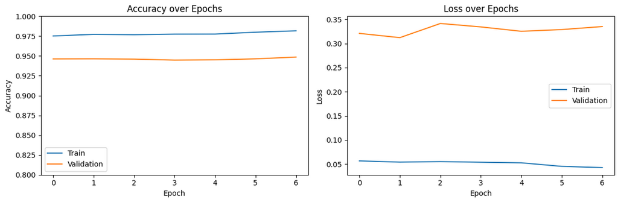

### Transpose VS No transpose curves

Without transposing, the training accuracy starts at 0.975 and stays flat while val accuracy stagnates around 0.947, with the loss gap staying wide (signs of overfitting / memorisation of the training data). The chart with transpose shows train accuracy starting lower and gradually catching up to validation, with the loss curves much closer together, showing more stable learning, better generalisation and reduced overfitting

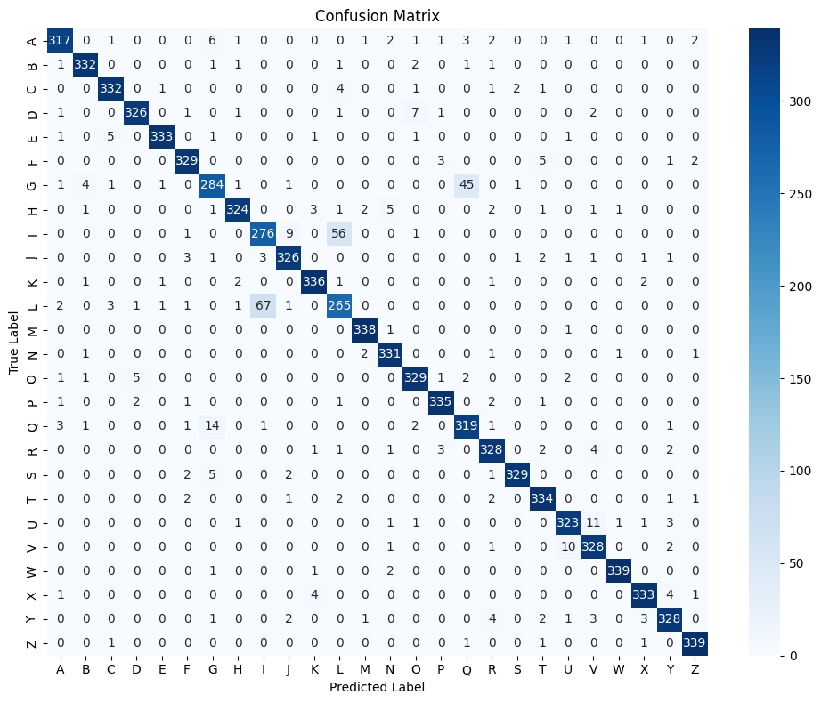

```
Macro Precision: 0.9476
Macro Recall:    0.9474
```

```python
# Get predictions
y_pred = model.predict(X_test).argmax(axis=1)
y_true = y_test.argmax(axis=1)

# Confusion matrix
plt.figure(figsize=(10, 8))
cm = confusion_matrix(y_true, y_pred)
sns.heatmap(cm, annot=True, fmt='d', cmap='Blues',
            xticklabels=[chr(ord('A') + i) for i in range(26)],
            yticklabels=[chr(ord('A') + i) for i in range(26)])
plt.title('Confusion Matrix')
plt.xlabel('Predicted Label')
plt.ylabel('True Label')
plt.tight_layout()
plt.show()

# Precision and recall
print(f"Macro Precision: {precision_score(y_true, y_pred, average='macro'):.4f}")
print(f"Macro Recall: {recall_score(y_true, y_pred, average='macro'):.4f}")
```

## Confusion matrix analysis

This graph shows which letters the model gets confused with, e.g. the model predicted a different letter than the actual one

- **I / L**: The most confused pair (123). This is expected as both letters are vertical lines; small l and big I look almost identical.
- **G / Q**: Circular shapes with small differences that are hard to capture at 28x28 resolution (59 errors).
- **U / V**: 21 errors total: 11 cases of U being predicted as V, and 10 cases of V being predicted as U.

# Second Model - Improved Architecture with Data Augmentation

The baseline achieved 0.9474 test accuracy but two problems are visible from the training curves: a train-val loss gap of 0.076 suggesting overfitting, and the Flatten + Dense(256) layer creating 295,168 weights in a single step. The second model will use improved architecture and data augmentation to fix these problems.

### Why Data Augmentation

Augmentation artificially increases training data variety by applying small transformations:

- Rotation (10 degrees): simulates natural handwriting tilt variation
- Width/height shift (0.1): simulates letters not perfectly centered in the image
- Zoom (0.1): simulates different handwriting sizes
- No horizontal flip: flipping would corrupt labels, e.g. b becomes d, p becomes q

```python
from tensorflow.keras.preprocessing.image import ImageDataGenerator
datagen = ImageDataGenerator(
    rotation_range=10,
    width_shift_range=0.1,
    height_shift_range=0.1,
    zoom_range=0.1
)

datagen.fit(X_train)
```

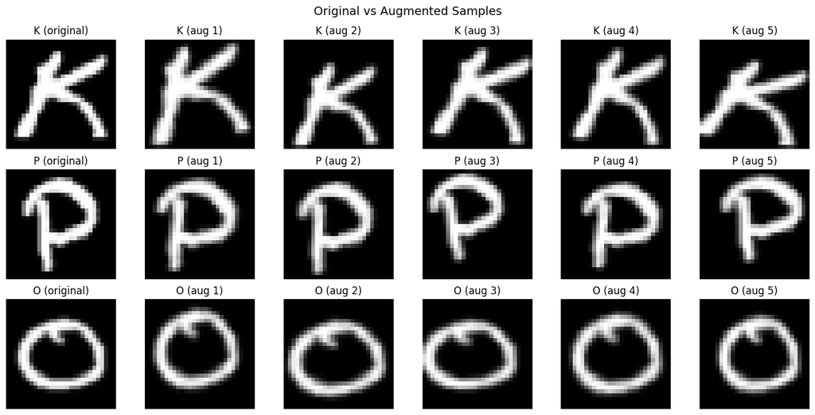

```python
# Visualise what the augmentation actually does to the images
fig, axes = plt.subplots(3, 6, figsize=(14, 7))

for row in range(3):
    # Pick a random training image
    idx = np.random.randint(0, len(X_train))
    img = X_train[idx]
    label = chr(ord('A') + y_train[idx].argmax())

    # Show original
    axes[row, 0].imshow(img.reshape(28, 28), cmap='gray')
    axes[row, 0].set_title(f'{label} (original)')
    axes[row, 0].axis('off')

    # Show 5 augmented versions
    aug_iter = datagen.flow(img.reshape(1, 28, 28, 1), batch_size=1)
    for col in range(1, 6):
        aug_img = next(aug_iter)[0]
        axes[row, col].imshow(aug_img.reshape(28, 28), cmap='gray')
        axes[row, col].set_title(f'{label} (aug {col})')
        axes[row, col].axis('off')

plt.suptitle('Original vs Augmented Samples', fontsize=14)
plt.tight_layout()
plt.show()
```

### Augmentation Visualisation

The augmented images show slight rotations, shifts and zooms compared to the originals. The transformations are small enough that the letters are still clearly readable, which means the model gets useful variation without learning from corrupted data. No horizontal flip is used since flipping would turn some letters into different ones, e.g. b becomes d.

## V2 Architecture Justification

```python
from tensorflow.keras.layers import GlobalAveragePooling2D
from tensorflow.keras.regularizers import l2

model_v2 = Sequential([
    Conv2D(32, (3,3), activation='relu', input_shape=(28,28,1), padding='same'),
    BatchNormalization(),
    MaxPooling2D((2,2)),

    Conv2D(64, (3,3), activation='relu', padding='same'),
    BatchNormalization(),
    MaxPooling2D((2,2)),

    Conv2D(128, (3,3), activation='relu', padding='same'),
    BatchNormalization(),
    Conv2D(128, (3,3), activation='relu', padding='same'),
    BatchNormalization(),

    GlobalAveragePooling2D(),
    Dense(256, activation='relu', kernel_regularizer=l2(0.001)),
    Dropout(0.4),
    Dense(26, activation='softmax')
])
```

```python
model_v2.compile(optimizer='adam',
                 loss='categorical_crossentropy',
                 metrics=['accuracy'])
```

```python
# Separate callbacks for V2 with correct checkpoint filename
callbacks_v2 = [
    EarlyStopping(monitor='val_loss', patience=5, restore_best_weights=True),
    ModelCheckpoint('best_model_partA_v2.h5', monitor='val_accuracy', save_best_only=True),
    ReduceLROnPlateau(monitor='val_loss', patience=3, factor=0.5, min_lr=1e-6)
]

history_v2 = model_v2.fit(
    datagen.flow(X_train, y_train, batch_size=32),
    epochs=50,
    validation_data=(X_val, y_val),
    callbacks=callbacks_v2
)

loss_v2, accuracy_v2 = model_v2.evaluate(X_test, y_test)
print(f'Model V2 Test Accuracy: {accuracy_v2:.4f}')
```

```
Model V2 Test Accuracy: 0.9604
```

```python
# Compare parameter counts between V1 and V2
print("V1 Baseline")
model.summary()
print("\nV2 Improved")
model_v2.summary()
```

```
V1 Baseline
Model: "sequential"
_________________________________________________________________
 Layer (type)                Output Shape              Param #
=================================================================
 conv2d (Conv2D)             (None, 26, 26, 32)        320

 batch_normalization (BatchN  (None, 26, 26, 32)       128
 ormalization)

 max_pooling2d (MaxPooling2D  (None, 13, 13, 32)       0
 )

 conv2d_1 (Conv2D)           (None, 11, 11, 64)        18496

 batch_normalization_1 (Batc  (None, 11, 11, 64)       256
 hNormalization)

 max_pooling2d_1 (MaxPooling  (None, 5, 5, 64)         0
 2D)

 conv2d_2 (Conv2D)           (None, 3, 3, 128)         73856

 batch_normalization_2 (Batc  (None, 3, 3, 128)        512
 hNormalization)

 flatten (Flatten)           (None, 1152)              0

 dense (Dense)               (None, 256)               295168

 dropout (Dropout)           (None, 256)               0

 dense_1 (Dense)             (None, 26)                6682

=================================================================
Total params: 395,418
Trainable params: 394,970
Non-trainable params: 448
_________________________________________________________________

```

[output cut: 30 more lines]

```

 global_average_pooling2d (G  (None, 128)              0
 lobalAveragePooling2D)

 dense_2 (Dense)             (None, 256)               33024

 dropout_1 (Dropout)         (None, 256)               0

 dense_3 (Dense)             (None, 26)                6682

=================================================================
Total params: 281,370
Trainable params: 280,666
Non-trainable params: 704
_________________________________________________________________
```

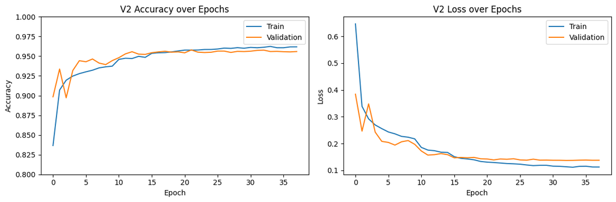

```python
# V2 Training curves
plt.figure(figsize=(12, 4))

plt.subplot(1, 2, 1)
plt.plot(history_v2.history['accuracy'], label='Train')
plt.plot(history_v2.history['val_accuracy'], label='Validation')
plt.title('V2 Accuracy over Epochs')
plt.xlabel('Epoch')
plt.ylabel('Accuracy')
plt.ylim([0.8, 1])
plt.legend()

plt.subplot(1, 2, 2)
plt.plot(history_v2.history['loss'], label='Train')
plt.plot(history_v2.history['val_loss'], label='Validation')
plt.title('V2 Loss over Epochs')
plt.xlabel('Epoch')
plt.ylabel('Loss')
plt.legend()

plt.tight_layout()
plt.show()
```

## V2 Training Evaluation

### Overfitting comparison

| Metric | V1 (Epoch 12) | V2 (Epoch 33) |
| --- | --- | --- |
| Train Loss | 0.1088 | 0.1134 |
| Val Loss | 0.1848 | 0.1370 |
| Gap | 0.0760 | 0.0236 |
| Test Accuracy | 0.9474 | 0.9604 |

V1's train loss is lower than V2's, but that is a sign of overfitting the model is memorising the training data too well. V2 has a lower val loss (0.14 vs 0.18), which is what actually matters since it measures performance on unseen data. The overfitting gap dropped from 0.076 to 0.024, roughly a 3x reduction.

### Training dynamics

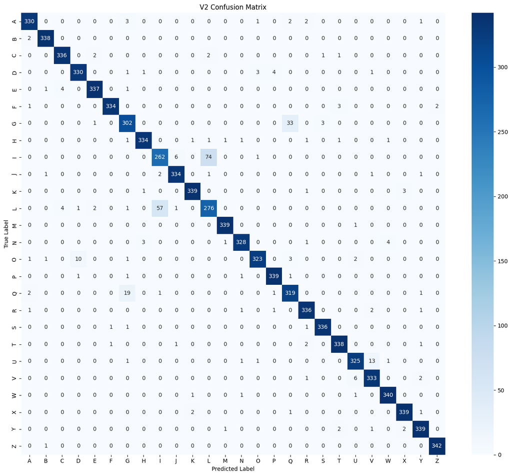

```
Macro Precision: 0.9604
Macro Recall:    0.9604
```

```python
y_pred_v2 = model_v2.predict(X_test).argmax(axis=1)
y_true = y_test.argmax(axis=1)

plt.figure(figsize=(14, 12))
cm_v2 = confusion_matrix(y_true, y_pred_v2)
sns.heatmap(cm_v2, annot=True, fmt='d', cmap='Blues',
            xticklabels=[chr(ord('A') + i) for i in range(26)],
            yticklabels=[chr(ord('A') + i) for i in range(26)])
plt.title('V2 Confusion Matrix')
plt.xlabel('Predicted Label')
plt.ylabel('True Label')
plt.tight_layout()
plt.show()

print(f"Macro Precision: {precision_score(y_true, y_pred_v2, average='macro'):.4f}")
print(f"Macro Recall:    {recall_score(y_true, y_pred_v2, average='macro'):.4f}")
```

## V2 Confusion Matrix Analysis

V2 achieved a significant improvement in macro precision and recall over V1, rising from ~0.95 to ~0.96.

### Still confused pairs

The same structurally similar letters remain the hardest to distinguish:

- **I / L**: Still the most confused pair, though errors increased from **123 to 131**.
- **G / Q**: Errors dropped from **59 to 52**.
- **U / V**: Total errors reduced to 19, but the split changed from 11 predicted as V to 13, and 10 predicted as U to 6. This shows that while augmentation helped overall, some letters just look too similar at 28x28 resolution for the model to ever be 100% sure.

### What improved

Data augmentation helped reduce errors on letters that vary a lot in tilt and position, e.g. K, R, T, since the model now sees rotated and shifted versions during training. The overall accuracy increased because the model became more robust to variations in handwriting.

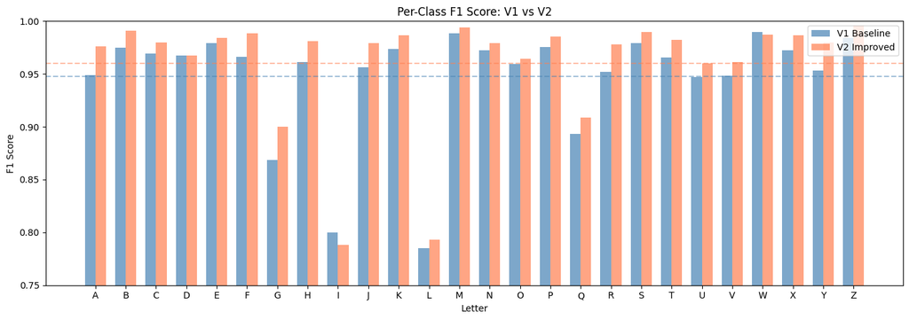

```
Top 5 letters with biggest F1 improvement (V1 → V2):
  G: 0.8685 → 0.9001 (+0.0316)
  A: 0.9491 → 0.9763 (+0.0272)
  Y: 0.9535 → 0.9798 (+0.0263)
  R: 0.9521 → 0.9782 (+0.0261)
  J: 0.9560 → 0.9795 (+0.0235)

3 weakest letters in V2:
  I: F1 = 0.7880
  L: F1 = 0.7931
  G: F1 = 0.9001
```

```python
# Per-class F1 score comparison between V1 and V2
from sklearn.metrics import f1_score

letters = [chr(ord('A') + i) for i in range(26)]

f1_v1 = f1_score(y_true, y_pred, average=None)
f1_v2_scores = f1_score(y_true, y_pred_v2, average=None)

# Bar chart comparison
fig, ax = plt.subplots(figsize=(14, 5))
x = np.arange(26)
width = 0.35
ax.bar(x - width/2, f1_v1, width, label='V1 Baseline', color='steelblue', alpha=0.7)
ax.bar(x + width/2, f1_v2_scores, width, label='V2 Improved', color='coral', alpha=0.7)

ax.set_xlabel('Letter')
ax.set_ylabel('F1 Score')
ax.set_title('Per-Class F1 Score: V1 vs V2')
ax.set_xticks(x)
ax.set_xticklabels(letters)
ax.set_ylim([0.75, 1.0])
ax.legend()
ax.axhline(y=np.mean(f1_v1), color='steelblue', linestyle='--', alpha=0.5)
ax.axhline(y=np.mean(f1_v2_scores), color='coral', linestyle='--', alpha=0.5)
plt.tight_layout()
plt.show()

# Top 5 improved and 3 weakest
improvement = f1_v2_scores - f1_v1
top5 = np.argsort(improvement)[::-1][:5]
print("Top 5 letters with biggest F1 improvement (V1 → V2):")
for idx in top5:
    print(f"  {letters[idx]}: {f1_v1[idx]:.4f} → {f1_v2_scores[idx]:.4f} (+{improvement[idx]:.4f})")

worst3 = np.argsort(f1_v2_scores)[:3]
print(f"\n3 weakest letters in V2:")
for idx in worst3:
    print(f"  {letters[idx]}: F1 = {f1_v2_scores[idx]:.4f}")
```

# Hyperparameter Tuning

Testing key hyperparameters individually to see how they impact V2's performance

The parameters being tested:

- **Dropout rate**: Controls how many neurons are randomly turned off during training. Too low = overfitting, too high = underfitting
- **L2 regularisation strength**: Controls how much the model is penalised for having large weights
- **Dense layer size**: Controls the capacity of the classification head

Each configuration uses the model V2 architecture and data augmentation, trained for up to 30 epochs to save time.

```python
# Hyperparameter tuning - test different configurations
from tensorflow.keras.layers import GlobalAveragePooling2D
from tensorflow.keras.regularizers import l2

configs = [
    {'name': 'dropout=0.3', 'dropout': 0.3, 'l2_val': 0.001, 'dense': 256},
    {'name': 'dropout=0.5', 'dropout': 0.5, 'l2_val': 0.001, 'dense': 256},
    {'name': 'l2=0.0005', 'dropout': 0.4, 'l2_val': 0.0005, 'dense': 256},
    {'name': 'l2=0.002', 'dropout': 0.4, 'l2_val': 0.002, 'dense': 256},
    {'name': 'dense=128', 'dropout': 0.4, 'l2_val': 0.001, 'dense': 128},
]

hp_results = []

# Add V2 baseline results for comparison
hp_results.append({
    'name': 'V2 baseline (d=0.4, l2=0.001, dense=256)',
    'test_acc': accuracy_v2,
    'test_loss': loss_v2
})

for cfg in configs:
    print(f"\n{'='*50}")
    print(f"Training: {cfg['name']}")
    print(f"{'='*50}")

    hp_model = Sequential([
        Conv2D(32, (3,3), activation='relu', input_shape=(28,28,1), padding='same'),
        BatchNormalization(),
        MaxPooling2D((2,2)),

        Conv2D(64, (3,3), activation='relu', padding='same'),
        BatchNormalization(),
        MaxPooling2D((2,2)),

        Conv2D(128, (3,3), activation='relu', padding='same'),
        BatchNormalization(),
        Conv2D(128, (3,3), activation='relu', padding='same'),
        BatchNormalization(),

        GlobalAveragePooling2D(),
        Dense(cfg['dense'], activation='relu', kernel_regularizer=l2(cfg['l2_val'])),
        Dropout(cfg['dropout']),
        Dense(26, activation='softmax')
    ])

    hp_model.compile(optimizer='adam',
                     loss='categorical_crossentropy',
                     metrics=['accuracy'])

    hp_callbacks = [
        EarlyStopping(monitor='val_loss', patience=5, restore_best_weights=True),
        ReduceLROnPlateau(monitor='val_loss', patience=3, factor=0.5, min_lr=1e-6)
    ]

    hp_model.fit(
        datagen.flow(X_train, y_train, batch_size=32),
        epochs=30,
        validation_data=(X_val, y_val),
        callbacks=hp_callbacks,
        verbose=1
    )

    hp_loss, hp_acc = hp_model.evaluate(X_test, y_test)
    hp_results.append({
        'name': cfg['name'],
        'test_acc': hp_acc,
        'test_loss': hp_loss
    })
    print(f"Test Accuracy: {hp_acc:.4f}")

# Print results table
print("\n" + "="*60)
print("HYPERPARAMETER TUNING RESULTS")
print("="*60)
print(f"{'Configuration':<45} {'Test Acc':>10} {'Test Loss':>10}")
print("-"*65)
for r in hp_results:
    print(f"{r['name']:<45} {r['test_acc']:>10.4f} {r['test_loss']:>10.4f}")

# Find best config
best = max(hp_results, key=lambda x: x['test_acc'])
print(f"\nBest configuration: {best['name']} with test accuracy {best['test_acc']:.4f}")
```

```
==================================================
Training: dropout=0.3
==================================================
Test Accuracy: 0.9604

==================================================
Training: dropout=0.5
==================================================
Test Accuracy: 0.9598

==================================================
Training: l2=0.0005
==================================================
Test Accuracy: 0.9588

==================================================
Training: l2=0.002
==================================================
Test Accuracy: 0.9578

==================================================
Training: dense=128
==================================================
Test Accuracy: 0.9592

============================================================
HYPERPARAMETER TUNING RESULTS
============================================================
Configuration                                   Test Acc  Test Loss
-----------------------------------------------------------------
V2 baseline (d=0.4, l2=0.001, dense=256)          0.9604     0.1368
dropout=0.3                                       0.9604     0.1413
dropout=0.5                                       0.9598     0.1415
l2=0.0005                                         0.9588     0.1460
l2=0.002                                          0.9578     0.1415
dense=128                                         0.9592     0.1472

Best configuration: V2 baseline (d=0.4, l2=0.001, dense=256) with test accuracy 0.9604
```

### Hyperparameter Tuning Analysis

The V2 baseline (dropout=0.4, L2=0.001, dense=256) was the best at 0.9604 test accuracy, tying dropout=0.3 on accuracy but winning on loss (0.1368 vs 0.1413). All configs scored within ~0.3% of each other (0.9578–0.9604), showing the V2 hyperparameters were already near-optimal.

**Dropout**: Lowering to 0.3 matched baseline accuracy (0.9604) but with a higher loss, so it generalised slightly worse. Raising to 0.5 dropped accuracy to 0.9598, confirming heavy dropout is counterproductive once GAP and L2 are already regularising the model.

**L2 strength**: Moving L2 in either direction reduced accuracy with 0.0005 scoring 0.9588 and 0.002 scoring 0.9578 (the lowest of all configs).

**Dense layer size**: 128 units scored 0.9592, just below baseline.

Overall, the test score depended far more on data augmentation, feature engineering and architecture than on fine-tuning these hyperparameters.

# Final Summary

## Model Comparison

| Metric | V1 Baseline | V2 Improved |
| --- | --- | --- |
| Architecture | 3 conv blocks, Flatten, Dense(256) | 4 conv blocks (same padding), GAP, Dense(256) + L2 |
| Data Augmentation | None | Rotation, shift, zoom |
| Test Accuracy | 0.9474 | 0.9604 |
| Macro Precision | 0.9476 | 0.9604 |
| Macro Recall | 0.9474 | 0.9604 |
| Train-Val Gap | 0.0760 | 0.0236 |

## Conclusion

V2 lifted test accuracy from 0.9474 to 0.9604, with macro precision and recall both rising by ~1.3%. The bigger problem was overfitting where the train-val loss gap dropped from 0.076 to 0.024, roughly 3x smaller, which is what actually matters for generalisation on unseen handwriting.

- **Data augmentation** had the biggest impact by adding rotation, shift and zoom addressed the overfitting from V1 by giving the model more varied training data instead of just suppressing memorisation with regularisation. This shows up more clearly in the gap reduction than in the raw accuracy improvement.
- **Image transpose was essential during preprocessing**. Without it, the model trained on mirrored letters and had a much wider overfitting gap (~0.25 vs ~0.08 after transpose)
- **Hyperparameter tuning** confirmed the V2 defaults were near-optimal, all 5 tested configurations scored within 0.4% of each other (0.9578–0.9604), meaning the architecture and augmentation choices mattered far more than fine-tuning individual hyperparameters.
- **Some errors are unavoidable at 28x28 resolution**. I/L remains the most confused pair with 131 errors in V2, since lowercase l and uppercase I are merged into the same class and look almost identical. This sets a natural ceiling on what the model can achieve without higher-resolution input data.
- **Callbacks were important for both models**. EarlyStopping prevented wasted compute and restored the best weights, while ReduceLROnPlateau let the learning rate drop from 1e-3 down to 3.13e-5 for V2, enabling finer weight updates near convergence.